# YieldSAT ML Tutorial

This notebook accompanies the YieldSAT paper:

> *YieldSAT: A Multimodal Benchmark Dataset for High-Resolution Crop Yield Prediction*  
> CVPR 2026 — [Project Page](https://yieldsat.github.io/)

to illustrate is ML-readiness. Using the preprocessed [`xarray.Dataset`](https://docs.xarray.dev/en/latest/user-guide/data-structures.html#dataset) datastructure, we can build fast and flexible models on multimodal input data.

1. open the preprocessed NetCDF file,
2. filter the dataset to one crop such as rapeseed,
3. build leakage-free cross-validation splits at field level,
4. wrap the data in a PyTorch `Dataset`, and
5. train a small ML regressor with the Pytorch API,
6. evaluate the predictions at various levels.

The example uses only Sentinel-2 bands to keep the model and feature tensor small.

## 1. `xarray` for ML Development

The preprocessed YieldSAT release is the model-ready version of the dataset. It is stored as an [`xarray.Dataset`](https://docs.xarray.dev/en/latest/user-guide/data-structures.html#dataset), which makes it convenient to train machine learning models, inspect metadata, and select subsets by country, crop, year, farm, or field.

In this format, each valid 10 m pixel is represented as a season-aligned temporal sample. The temporal representation contains **24 time steps** spanning a two-calendar-year window defined relative to seeding and harvesting, such that the harvest month always lies in the second year. For each time step, the selected observation corresponds to the least-cloudy available image, and observations outside the growing season are masked. All input modalities are aligned via concatenation and temporal and spatial repetition (input fusion), resulting in a standardized tensor representation.

We provide detailed information about the `xarray` data structure in the data overview `Notebook`.

```python
import matplotlib.pyplot as plt
import numpy as np
import os
from pathlib import Path
import xarray as xr
from pprint import pprint
import pandas as pd
import warnings
warnings.filterwarnings('ignore')
plt.style.use("seaborn-v0_8-whitegrid")
pd.options.display.max_columns = 200
pd.options.display.width = 120
```

`preprocessed-24-ts/` contains one model-ready NetCDF file per country. For this tutorial, we select the .nc file for Germany because of its smaller size.

## Xarray Data Format for Pixel-Wise Yield Prediction

The xarray (netcdf) data format is a processed version of the YieldSAT dataset, ready for training DL models at the pixel level. The data uses a unified time series of 24 time steps, including all data modalities. Each Modality is aligned in time and space using concatenation and spatial repetition at the input level (input fusion). The processing is described and referenced in the main paper. We provide the processed data for each country separately. Each country then contains all the crop types available in that country.

For more information on Xarray, see: https://docs.xarray.dev/en/latest/index.html

The netCDF file has the following structure:

**Coordinates**:

- bands: Input modalities (S2 + ADM)
- index: Pixel index
- time_step: time step

**Data Variables**

- target: target yield value (t/ha)
- sample: input of multimodal time series (index, time_step, band)
- col: column index in the image $index_i$
- row: row index in the image for $index_i$
- crop: crop type information
- farm_identifier: unique ID for a farm (region)
- seeding_date: seeding data for yield $index_i$
- harvesting_date: harvesting data for yield $index_i$
- year: year of harvest

**Attributes**

- further metadata for each field

```python
DATA_ROOT = Path("") # update this to path where you organize the data
PREPROCESSED_ROOT = DATA_ROOT / "preprocessed-24-ts/"

COUNTRY = "Germany"

TARGET_CROP = "rapeseed"

preprocessed_path = PREPROCESSED_ROOT / COUNTRY / "merged" / "merge_s2-soil-dem-weather-coords.nc"

assert PREPROCESSED_ROOT.exists(), PREPROCESSED_ROOT
assert preprocessed_path.exists(), preprocessed_path
```

```python
#reading netcdf file
ds = xr.open_dataset(preprocessed_path)
ds
```

```
<xarray.Dataset>
Dimensions:            (index: 609645, time_step: 24, band: 120)
Coordinates:
  * index              (index) object '5d35849b-ace1-4dd4-962d-da80c6c56bac' ...
  * time_step          (time_step) int64 0 1 2 3 4 5 6 ... 17 18 19 20 21 22 23
  * band               (band) object 'B01' 'B02' 'B03' ... 'coord_y' 'coord_z'
Data variables: (12/17)
    target             (index) float32 ...
    times              (index, time_step) datetime64[ns] ...
    seeding_date       (index) uint8 ...
    harvesting_date    (index) uint8 ...
    farm_identifier    (index) uint8 ...
    country            (index) uint8 ...
    ...                 ...
    col                (index) uint8 ...
    stats-mean         (band) float32 469.2 566.0 864.8 ... -0.2598 0.443
    stats-min          (band) float32 0.0 1.0 1.0 ... -0.8557 -0.9154 -0.5302
    stats-max          (band) float32 8.976e+03 4.396e+03 ... 0.4852 0.9992
    stats-std          (band) float32 273.9 260.7 327.6 ... 0.2491 0.4512 0.6131
    sample             (index, time_step, band) float32 ...
Attributes: (12/299)
    Germany_DUP3_farm5_field265_rapeseed_2020_<>_yield_ground_truth:  2.892
    Germany_DUP3_farm2_field170_wheat_2019_<>_yield_ground_truth:     9.16
    Germany_DUP3_farm1_field13_rapeseed_2016_<>_yield_ground_truth:   3.03555...
    Germany_DUP3_farm1_field52_wheat_2019_<>_yield_ground_truth:      7.45555...
    Germany_DUP3_farm2_field128_wheat_2019_<>_yield_ground_truth:     7.94
    Germany_DUP3_farm6_field285_rapeseed_2020_<>_yield_ground_truth:  3.87
    ...                                                               ...
    Germany_DUP3_farm5_field269_rapeseed_2017_<>_yield_ground_truth:  2.205
    Germany_DUP3_farm2_field105_wheat_2019_<>_yield_ground_truth:     9.84
    Germany_DUP3_farm6_field281_rapeseed_2019_<>_yield_ground_truth:  3.74
    Germany_DUP3_farm2_field99_wheat_2018_<>_yield_ground_truth:      7.65
    Germany_DUP3_farm5_field275_rapeseed_2018_<>_yield_ground_truth:  4.454
    Germany_DUP3_farm6_field278_rapeseed_2018_<>_yield_ground_truth:  3.8
```

```python
print(f"Dataset sizes: \n{dict(ds.sizes)} \n")
print("Available crops:")
print({int(k): v for k, v in ds["crop"].attrs.items()})

print(f"\nThe datset contains two crop types (rapeseed and wheat). Since we want to train a single class model ({TARGET_CROP}), we must filter the dataset.")
```

```
Dataset sizes:
{'index': 609645, 'time_step': 24, 'band': 120}

Available crops:
{0: 'rapeseed', 1: 'wheat'}

The datset contains two crop types (rapeseed and wheat). Since we want to train a single class model (rapeseed), we must filter the dataset.
```

```python
ds["crop"] # The crop types are stored in the attrs of the datset and are encoded.
```

```
<xarray.DataArray 'crop' (index: 609645)>
[609645 values with dtype=uint8]
Coordinates:
  * index    (index) object '5d35849b-ace1-4dd4-962d-da80c6c56bac' ... 'fc0f3...
Attributes:
    0:        rapeseed
    1:        wheat
```

```python
def filter_ds_by_attribute(dataset: xr.Dataset, filter_variable: str="crop", condition=None) -> xr.Dataset:
    """Filter a dataset by attribuites

    Args:
    -----
        dataset: xr dataset
        filter_criterion: (str) variable to filter
        condition: (str) filter condition

    Returns:
    --------
        filtered xr dataset

    """
    mapping = dict((v, k) for k, v in dataset[filter_variable].attrs.items())
    filter_val = [int(mapping[condition])]
    selected_ind = dataset.data_vars[filter_variable].isin(filter_val)
    dataset = dataset.sel(index=selected_ind)

    for k in mapping.keys(): # drop other attributes
        if k != condition:
            del dataset[filter_variable].attrs[mapping[k]]

    field_id = dataset["field_shared_name"]
    unique_field_id = np.unique(field_id.values) #farms that are still in data
    attrs_field_id = [int(v) for v in field_id.attrs.keys()]
    fields_to_delete_name = []

    for fields_delete in list(set(attrs_field_id) - set(unique_field_id) ):
        fields_to_delete_name.append(field_id.attrs[str(fields_delete)])
        del field_id.attrs[str(fields_delete)]

    for info in dataset.attrs.copy():
        if info.split("_<>_")[0] in fields_to_delete_name:
            del dataset.attrs[info]
    return dataset
```

```python
#filter dataset by crop type
filtered_ds = filter_ds_by_attribute(ds, filter_variable="crop", condition=TARGET_CROP)
filtered_ds
```

```
<xarray.Dataset>
Dimensions:            (index: 302802, time_step: 24, band: 120)
Coordinates:
  * index              (index) object '5d35849b-ace1-4dd4-962d-da80c6c56bac' ...
  * time_step          (time_step) int64 0 1 2 3 4 5 6 ... 17 18 19 20 21 22 23
  * band               (band) object 'B01' 'B02' 'B03' ... 'coord_y' 'coord_z'
Data variables: (12/17)
    target             (index) float32 ...
    times              (index, time_step) datetime64[ns] ...
    seeding_date       (index) uint8 ...
    harvesting_date    (index) uint8 ...
    farm_identifier    (index) uint8 ...
    country            (index) uint8 ...
    ...                 ...
    col                (index) uint8 ...
    stats-mean         (band) float32 469.2 566.0 864.8 ... -0.2598 0.443
    stats-min          (band) float32 0.0 1.0 1.0 ... -0.8557 -0.9154 -0.5302
    stats-max          (band) float32 8.976e+03 4.396e+03 ... 0.4852 0.9992
    stats-std          (band) float32 273.9 260.7 327.6 ... 0.2491 0.4512 0.6131
    sample             (index, time_step, band) float32 ...
Attributes: (12/111)
    Germany_DUP3_farm5_field265_rapeseed_2020_<>_yield_ground_truth:  2.892
    Germany_DUP3_farm1_field13_rapeseed_2016_<>_yield_ground_truth:   3.03555...
    Germany_DUP3_farm6_field285_rapeseed_2020_<>_yield_ground_truth:  3.87
    Germany_DUP3_farm2_field169_rapeseed_2018_<>_yield_ground_truth:  3.59
    Germany_DUP3_farm1_field14_rapeseed_2016_<>_yield_ground_truth:   1.35666...
    Germany_DUP3_farm6_field290_rapeseed_2021_<>_yield_ground_truth:  2.38
    ...                                                               ...
    Germany_DUP3_farm6_field280_rapeseed_2019_<>_yield_ground_truth:  2.87
    Germany_DUP3_farm6_field294_rapeseed_2016_<>_yield_ground_truth:  3.97
    Germany_DUP3_farm5_field269_rapeseed_2017_<>_yield_ground_truth:  2.205
    Germany_DUP3_farm6_field281_rapeseed_2019_<>_yield_ground_truth:  3.74
    Germany_DUP3_farm5_field275_rapeseed_2018_<>_yield_ground_truth:  4.454
    Germany_DUP3_farm6_field278_rapeseed_2018_<>_yield_ground_truth:  3.8
```

```python
print(f"Filtered Dataset size: \n{dict(filtered_ds.sizes)} \n")
print("Available crops after filterin:")
print({int(k): v for k, v in filtered_ds["crop"].attrs.items()})
```

```
Filtered Dataset size:
{'index': 302802, 'time_step': 24, 'band': 120}

Available crops after filterin:
{0: 'rapeseed'}
```

## 2. Dataset and Grouped Train/Test Splitting

This cell defines a Pytorch `YieldSATDataset` class and performs a grouped split by `field_id` for robust cross-validation. The goal is to prevent leakage from the same field between train/test folds.

```python
from torch.utils.data import Dataset, DataLoader
import torch
```

```python
# Check if cuda is available for faster GPU training
torch.cuda.is_available()
```

```
True
```

```python
class YieldSATDataset(Dataset):
    def __init__(self,
                 data: str,
                 fill_value=-1,
                 band=['B01', 'B02', 'B03', 'B04', 'B05', 'B06', 'B07', 'B08', 'B8A', 'B09','B11', 'B12',], #S2 only for demonstration. Include other available features as required
                 indices=None,
                ):
        super().__init__()

        self.data_path = data
        self.indices = indices
        self.fill_value = fill_value
        self.band= band

        if isinstance(data, (Path, str)):
            assert os.path.exists(data), f"Dataset file {data} not found."
            self.ds = xr.open_dataset(data).load()
        else:
            self.ds = data.load()

        self.ds["sample"] = self.ds["sample"].fillna(fill_value)
        self.num_features = self.ds.band.values.size
        self.len_sequence = self.ds.time_step.values.size

        #filter dataset for selected indices for CV training
        if self.indices is not None:
            self.ds = self.ds.sel(index=self.indices)

        #filter dataset for selected bands
        if self.band != []:
            self.ds = self.ds.sel(band=band)

        self.index_ids = list(self.ds.coords["index"].values)

    def __len__(self):
        return len(self.ds["sample"])

    def __getitem__(self, idx):
        sample = self.ds['sample'].isel(index=idx).values.astype(np.float32)
        target = self.ds['target'].isel(index=idx).values.astype(np.float32)
        index = str(self.ds['index'].isel(index=idx).values)
        sample = np.nan_to_num(sample, nan=-1.0, posinf=-1.0, neginf=-1.0)
        return {"sample": torch.tensor(sample, dtype=torch.float32), "target": torch.tensor(target, dtype=torch.float32), "index": index}
```

### 3. Group-K-Fold Cross-Validation

We create a simple dataset splitting for CV training by ensuring that pixels (index) from the same field are either in train or val to avoid information leakage. We can create more advances splittings (e.g., stratifying by region, leave-one-year-out, or leave-one-region-out etc.), to ensure a more realistic training setup.

```python
from sklearn.model_selection import GroupKFold
import random
random.seed(0)
```

```python
def split_dataset_by_group(data: str, n_splits: int=5, group_key: str=None) -> list:
    """Create train/val splits for CV training based on group-k-fold CV.

    This ensures that pixels from the same field are either in train or in val.

    Parameters:
    -----------
        data_path: path to .nc dataset
        n_splits: number of folds
        group_key : key used for grouping

    Returns:
    --------
        list of splits
    """
    if isinstance(data, (str, Path)):
        assert os.path.exists(data), f"Dataset file {data} not found."
        data = xr.open_dataset(data)

    indices = data.coords["index"].values.tolist()
    random.shuffle(indices)
    groups = data[group_key].sel(index=indices).values if group_key is not None else None
    if group_key is not None:
        inst = GroupKFold(n_splits=n_splits)
        splits = [
            (np.take(indices, train_ind).tolist(), np.take(indices, val_ind).tolist())
            for train_ind, val_ind in inst.split(indices, groups=groups)
        ]
    for split_i in splits:
            assert set(split_i[0]).isdisjoint(set(split_i[1])), "sets overlap"
    return splits

splits = split_dataset_by_group(data=filtered_ds, n_splits=2, group_key="field_shared_name")
print(f"Number of splits for CV training: {len(splits)}")
```

```
Number of splits for CV training: 2
```

## 4. LSTM Model and Training

We define a minimal Pytorch LSTM model and a training pipeline. We will train the model on a Group-K-Fold cross-validation split and evaluate on a seperate validation set using common regression metrics. You can replace it with your model of choice.

```python
class LSTM_Model(torch.nn.Module):
    def __init__(self, input_dim, hidden_dim=64, num_layers=1):
        super().__init__()
        self.lstm = torch.nn.LSTM(input_size=input_dim, hidden_size=hidden_dim, num_layers=num_layers, batch_first=True)
        self.fc = torch.nn.Linear(hidden_dim, 1)

    def forward(self, x):
        out, _ = self.lstm(x)
        out = out[:, -1, :]
        out = self.fc(out)
        return out.squeeze(1)
```

```python
from sklearn.metrics import mean_squared_error, r2_score

def model_training(model, train_loader, criterion, optimizer, device):
    train_loss = 0
    for idx, sample_batch in enumerate(train_loader):
        sample = sample_batch["sample"].to(device)
        target = sample_batch["target"].to(device)
        optimizer.zero_grad()
        preds = model(sample)
        loss = criterion(preds, target)
        loss.backward()
        optimizer.step()
        train_loss += loss.item() * preds.size(0)

    total_loss = train_loss / len(train_loader)
    print(f"total train loss: {total_loss:.2f}")


def model_validation(model, val_loader, criterion, device, BEST_R2_SCORE):
    val_loss = 0
    predictions = []
    targets = []
    indices = []
    for idx, sample_batch in enumerate(val_loader):
        sample = sample_batch["sample"].to(device)
        target = sample_batch["target"].to(device)
        index = sample_batch["index"]
        with torch.no_grad():
            preds = model(sample)
        loss = criterion(preds, target)
        val_loss += loss.item() * preds.size(0)
        predictions.extend(preds.detach().cpu().numpy())
        targets.extend(target.detach().cpu().numpy())
        indices.extend(index)

    total_val_loss = val_loss / len(val_loader)
    print(f"total val loss: {total_val_loss:.2f}")

    ep_r2 = r2_score(targets, predictions)
    if ep_r2 > BEST_R2_SCORE:
        BEST_R2_SCORE = ep_r2
        print(f"New best R2-Score: {BEST_R2_SCORE:.2f}")

    val_df = pd.DataFrame({
        "index": indices,
        "target": targets,
        "prediction": predictions,
    })
    return val_df, BEST_R2_SCORE
```

```python
# CV training
n_splits = 2 #Only 2 for demonstration
n_epochs = 15
cv_predictions = []
for cv_i in range(n_splits):
    train_indices, val_indices = splits[cv_i]
    print(f"xxxxxxx Start CV Run : {cv_i} xxxxxxx")
    print("Nr. training indices:", len(train_indices))
    print("Nr. validation indices:", len(val_indices))

    train_dataset = YieldSATDataset(data=preprocessed_path, indices=train_indices)
    val_dataset = YieldSATDataset(data=filtered_ds, indices=val_indices)
    num_workers = int(len(os.sched_getaffinity(0)) // 4)

    train_loader = torch.utils.data.DataLoader(
        dataset=train_dataset,
        shuffle=True,
        batch_size=1028,
        pin_memory=True,
        num_workers=num_workers
    )

    val_loader = torch.utils.data.DataLoader(
        dataset=val_dataset,
        shuffle=False,
        batch_size=1028,
        pin_memory=True,
        num_workers=num_workers
    )

    device = torch.device('cuda' if torch.cuda.is_available() else 'cpu')
    model = LSTM_Model(input_dim=12).to(device)

    criterion = torch.nn.MSELoss()
    optimizer = torch.optim.Adam(model.parameters(), lr=1e-3)

    BEST_R2_SCORE = -1e6
    for epoch in range(n_epochs):
        print(f"------- Epoch: {epoch} -------")
        model_training(model=model, train_loader=train_loader, criterion=criterion, optimizer=optimizer, device=device)
        val_df, BEST_R2_SCORE = model_validation(
            model=model,
            val_loader=val_loader,
            criterion=criterion,
            device=device,
            BEST_R2_SCORE=BEST_R2_SCORE,
        )
        val_df["cv_fold"] = cv_i
        val_df["epoch"] = epoch
        cv_predictions.append(val_df)
# concatenate per-fold prediction results and save them
cv_predictions_df = pd.concat(cv_predictions, ignore_index=True)
```

```
xxxxxxx Start CV Run : 0 xxxxxxx
Nr. training indices: 151165
Nr. validation indices: 151637
------- Epoch: 0 -------
total train loss: 4548.08
total val loss: 2993.71
New best R2-Score: 0.03
------- Epoch: 1 -------
total train loss: 2006.82
total val loss: 2560.84
New best R2-Score: 0.17
------- Epoch: 2 -------
total train loss: 1589.69
total val loss: 2476.71
New best R2-Score: 0.20
------- Epoch: 3 -------
total train loss: 1421.30
total val loss: 2351.50
New best R2-Score: 0.24
------- Epoch: 4 -------
total train loss: 1337.11
total val loss: 2353.96
------- Epoch: 5 -------
total train loss: 1266.23
total val loss: 2245.00
New best R2-Score: 0.27
------- Epoch: 6 -------
total train loss: 1251.52
total val loss: 2358.66
------- Epoch: 7 -------
total train loss: 1216.00
total val loss: 2286.11
------- Epoch: 8 -------
total train loss: 1180.61
total val loss: 2580.89
------- Epoch: 9 -------
total train loss: 1201.00
total val loss: 2339.74
------- Epoch: 10 -------
total train loss: 1167.83
```

[output cut: 53 more lines]

```
total val loss: 1964.07
New best R2-Score: 0.25
------- Epoch: 11 -------
total train loss: 1459.96
total val loss: 1985.62
------- Epoch: 12 -------
total train loss: 1432.80
total val loss: 2082.75
------- Epoch: 13 -------
total train loss: 1447.36
total val loss: 1983.69
------- Epoch: 14 -------
total train loss: 1406.08
total val loss: 1950.60
New best R2-Score: 0.25
```

```python
#stored results
cv_predictions_df
```

|  | index | target | prediction | cv_fold | epoch |
| --- | --- | --- | --- | --- | --- |
| 0 | 82fbc894-6ce3-462a-ac56-906f053416f8 | 4.460000 | 3.881447 | 0 | 0 |
| 1 | 90542626-23d3-4432-ae67-ced2b7dd93a0 | 4.633333 | 4.266084 | 0 | 0 |
| 2 | 96e1d447-8c55-411b-991c-54d3b7f3b89e | 4.365000 | 4.010424 | 0 | 0 |
| 3 | fd97ab25-00ee-4707-a0cd-d6b70fd41d09 | 7.495000 | 3.897541 | 0 | 0 |
| 4 | fd7e68d8-fa07-41dd-b375-a70e3c18b12d | 3.680000 | 4.050245 | 0 | 0 |
| ... | ... | ... | ... | ... | ... |
| 4542025 | fa0ddbe5-55dc-4ab9-b887-07f1c57da4a3 | 3.020000 | 3.367503 | 1 | 14 |
| 4542026 | d1c87a3f-b690-423e-8ccd-37eddd999518 | 1.524000 | 3.638667 | 1 | 14 |
| 4542027 | 6dce6c67-cc67-45ee-9ed2-4a8f5bb5cacf | 5.525000 | 5.277243 | 1 | 14 |
| 4542028 | bdaa9629-7468-4aac-b54c-8be6a1f9dd94 | 0.666667 | 1.536965 | 1 | 14 |
| 4542029 | 8b01960b-a8eb-4ad1-a171-baddeac026e7 | 4.397778 | 4.782866 | 1 | 14 |

4542030 rows × 5 columns

## 5. Evaluation: RMSE and R2

## 6. Pixel-level Evaluation

We can evaluate the predictions at the individual pixel level and over all CV folds.

```
Pixel-level RMSE: 1.4234
Pixel-level R2: 0.2747
```

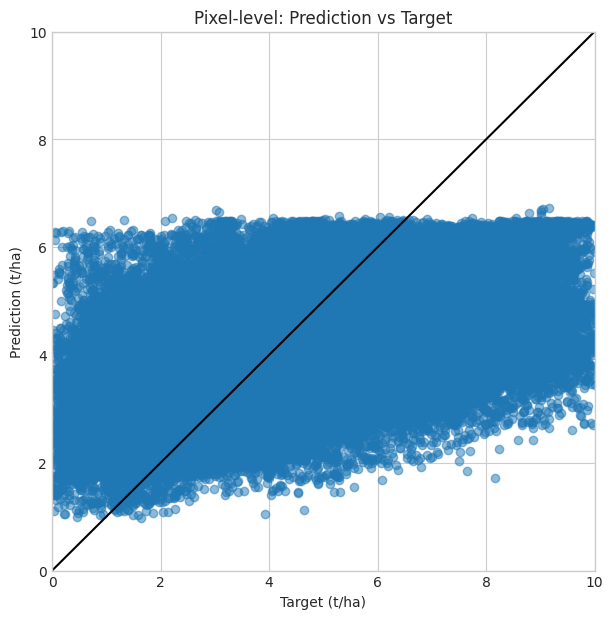

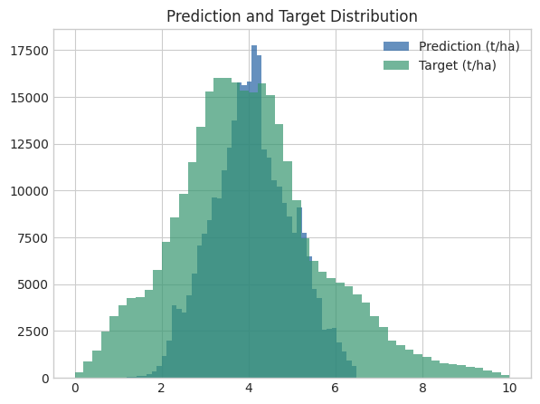

```python
# Average predictions per index over CV folds
pixel_avg = cv_predictions_df.groupby('index').agg({'prediction': 'mean', 'target': 'first'}).reset_index()


rmse_pixel = np.sqrt(mean_squared_error(pixel_avg['target'], pixel_avg['prediction']))
r2_pixel = r2_score(pixel_avg['target'], pixel_avg['prediction'])

print(f'Pixel-level RMSE: {rmse_pixel:.4f}')
print(f'Pixel-level R2: {r2_pixel:.4f}')

# Scatterplot
plt.figure(figsize=(7,7))
plt.scatter(pixel_avg['target'], pixel_avg['prediction'], alpha=0.5)
max_value = max(np.max(pixel_avg['target']), np.max(pixel_avg['prediction']))
min_value = min(np.min(pixel_avg['target']), np.min(pixel_avg['prediction']), 0)
plt.xlim(left=min_value, right=max_value)
plt.ylim(bottom=min_value, top=max_value)
plt.plot([min_value, max_value], [min_value, max_value], color="k", ls="-")


plt.xlabel('Target (t/ha)')
plt.ylabel('Prediction (t/ha)')
plt.title('Pixel-level: Prediction vs Target')
plt.show()

# Histograms
plt.figure(figsize=(15,5))
plt.subplot(1,2,1)
plt.hist(pixel_avg['prediction'], bins=50, fc=(0.14, 0.38, 0.64, 0.7), label='Prediction (t/ha)')
plt.title('Prediction Distribution')
plt.hist(pixel_avg['target'], bins=50, fc=(0.21, 0.59, 0.44, 0.7), label='Target (t/ha)')
plt.title('Prediction and Target Distribution')
plt.legend()
plt.show()
```

## 7. Field-level Evaluation

We can also group predictions by each fields and compare against the ground truth fields statistics.

```
Field-level RMSE: 0.9666
Field-level R2: 0.4815
```

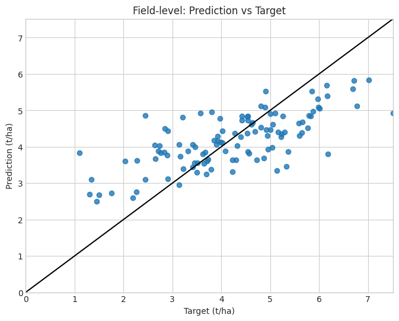

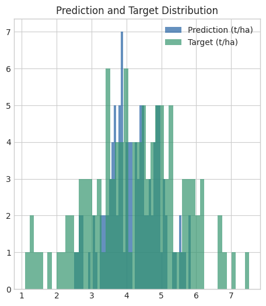

```python
# Load dataset to get field mapping
ds = xr.open_dataset(preprocessed_path)
field_mapping = ds[['index', 'field_shared_name']].to_dataframe().reset_index()

# Merge with pixel_avg to get field_shared_name
pixel_avg = pixel_avg.merge(field_mapping[['index', 'field_shared_name']], on='index', how='left')

# Group by field_shared_name and average predictions and targets
field_avg = pixel_avg.groupby('field_shared_name').agg({'prediction': 'mean', 'target': 'mean'}).reset_index()

# Compute RMSE and R2 at field level
rmse_field = np.sqrt(mean_squared_error(field_avg['target'], field_avg['prediction']))
r2_field = r2_score(field_avg['target'], field_avg['prediction'])

print(f'Field-level RMSE: {rmse_field:.4f}')
print(f'Field-level R2: {r2_field:.4f}')

# Scatterplot
plt.figure(figsize=(8,6))
plt.scatter(field_avg['target'], field_avg['prediction'], alpha=0.8)

max_value = max(np.max(field_avg['target']), np.max(field_avg['prediction']))
min_value = min(np.min(field_avg['target']), np.min(field_avg['prediction']), 0)
plt.xlim(left=min_value, right=max_value)
plt.ylim(bottom=min_value, top=max_value)
plt.plot([min_value, max_value], [min_value, max_value], color="k", ls="-")

plt.xlabel('Target (t/ha)')
plt.ylabel('Prediction (t/ha)')
plt.title('Field-level: Prediction vs Target')
plt.show()

# Histograms
plt.figure(figsize=(12,6))
plt.subplot(1,2,1)
plt.hist(field_avg['prediction'], bins=50, fc=(0.14, 0.38, 0.64, 0.7), label='Prediction (t/ha)')
plt.hist(field_avg['target'], bins=50, fc=(0.21, 0.59, 0.44, 0.7), label='Target (t/ha)')
plt.title('Prediction and Target Distribution')
plt.legend()
plt.show()
```

## 9. Field Prediction Visualization

Finally, we can also evaluate predictions at the spatial level by evaluate the entire fields of pixel-wise predictions.

```
Visualizing predictions for field: 4
```

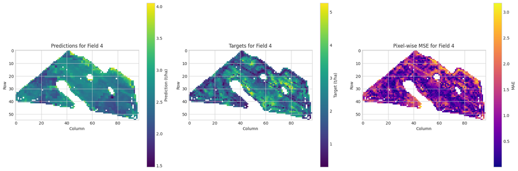

```python
# Choose a field to visualize (e.g., the first one)
field_name = field_avg['field_shared_name'].iloc[2]
print(f"Visualizing predictions for field: {field_name}")

# Get pixels for this field
field_pixels = pixel_avg[pixel_avg['field_shared_name'] == field_name]

# Load dataset to get row and col coordinates
ds = xr.open_dataset(preprocessed_path)
field_indices = field_pixels['index'].tolist()
field_ds = ds.sel(index=field_indices)

# Extract row, col, predictions, and targets
rows = field_ds['row'].values
cols = field_ds['col'].values
preds = field_pixels['prediction'].values
targets = field_pixels['target'].values

# Create 2D image arrays
# Shift coordinates to start from 0
min_row = rows.min()
min_col = cols.min()
row_shifted = rows - min_row
col_shifted = cols - min_col

# Determine image dimensions
max_row = int(row_shifted.max()) + 1
max_col = int(col_shifted.max()) + 1

# Initialize images with NaN
pred_image = np.full((max_row, max_col), np.nan)
target_image = np.full((max_row, max_col), np.nan)
mse_image = np.full((max_row, max_col), np.nan)

# Fill in values
for r, c, p, t in zip(row_shifted, col_shifted, preds, targets):
    pred_image[int(r), int(c)] = p
    target_image[int(r), int(c)] = t
    mse_image[int(r), int(c)] = abs(p - t)

# Plot the field predictions, targets, and MSE
fig, axes = plt.subplots(1, 3, figsize=(18, 6))

# Prediction
im1 = axes[0].imshow(pred_image, cmap='viridis', origin='upper')
axes[0].set_title(f'Predictions for Field {field_name}')
axes[0].set_xlabel('Column')
axes[0].set_ylabel('Row')
plt.colorbar(im1, ax=axes[0], label='Prediction (t/ha)')

# Target
im2 = axes[1].imshow(target_image, cmap='viridis', origin='upper')
axes[1].set_title(f'Targets for Field {field_name}')
axes[1].set_xlabel('Column')
axes[1].set_ylabel('Row')
plt.colorbar(im2, ax=axes[1], label='Target (t/ha)')

# MSE
im3 = axes[2].imshow(mse_image, cmap='plasma', origin='upper')
axes[2].set_title(f'Pixel-wise MSE for Field {field_name}')
axes[2].set_xlabel('Column')
axes[2].set_ylabel('Row')
plt.colorbar(im3, ax=axes[2], label='MAE')

plt.tight_layout()
plt.show()
```